# Improving Artificial Neural Network Training and Hyperparameter Tuning Times via Parallelization

Using the Caret Tuning and H2o Machine Learning Frameworks

Franklin Fuchs

# 1 Introduction

For this project, we will be using the Covertype dataset from the UCI Machine Learning Repository. This dataset contains 581,012 instances and 54 attributes, making it significantly larger and more complex than the iris dataset. The dataset is used to predict forest cover type from cartographic variables only (no remotely sensed data). The actual forest cover type for a given observation (30 x 30 meter cell) was determined from US Forest Service (USFS) Region 2 Resource Information System (RIS) data. Independent variables were derived from data originally obtained from US Geological Survey (USGS) and USFS data.

## 1.1 The DataSet

```r
# Load the Covertype dataset

# Define the column names
col_names <- c(paste0("V", 1:54), "Cover_Type")

# Define the URL of the dataset
url <- "https://archive.ics.uci.edu/ml/machine-learning-databases/covtype/covtype.data.gz"

# Load the Covertype dataset directly from the UCI repository
data <- read_csv(url, col_names = col_names)


sample_data <- function(data) {
  # Calculate the number of rows to sample
  sample_size <- nrow(data) / 50

  # Sample the data without replacement
  data <- data[sample(nrow(data), sample_size), ]

  return(data)
}

# Use the function to sample the data
data <- sample_data(data)
```

## 1.2 Caret and H2o

Caret (Classification And REgression Training) is a set of functions that attempt to streamline the process for creating predictive models. It provides a uniform interface to hundreds of machine learning algorithms in R and has useful functions for data splitting, pre-processing, feature selection, model tuning and more.

H2o is an open-source software for data analysis. It provides a platform for building machine learning models that can process data much faster than standard algorithms. It supports the most widely used machine learning algorithms, including generalized linear models, gradient boosting machines, random forest, deep learning, and many more.

## 1.3 Artificial Neural Networks

Artificial Neural Networks (ANNs) are a type of machine learning model that are inspired by the human brain. They consist of a large number of interconnected processing nodes, or “neurons”, each of which performs a simple computation. The power of neural networks comes from their ability to learn complex patterns and make predictions based on these patterns.

## 1.4 Parallelization

Parallelization is the process of dividing a large task into smaller sub-tasks that can be processed simultaneously. This can significantly reduce the time it takes to complete the task. In the context of this project, we will be using parallelization to speed up the training of our ANN models.

# 2 Data Preparation

```r
# Split the data into training and test sets
set.seed(123)
trainIndex <- createDataPartition(data$Cover_Type, p = .8,
                                  list = FALSE,
                                  times = 1)
trainData <- data[ trainIndex,]
testData  <- data[-trainIndex,]
```

## 2.1 Exploratory Data Analysis

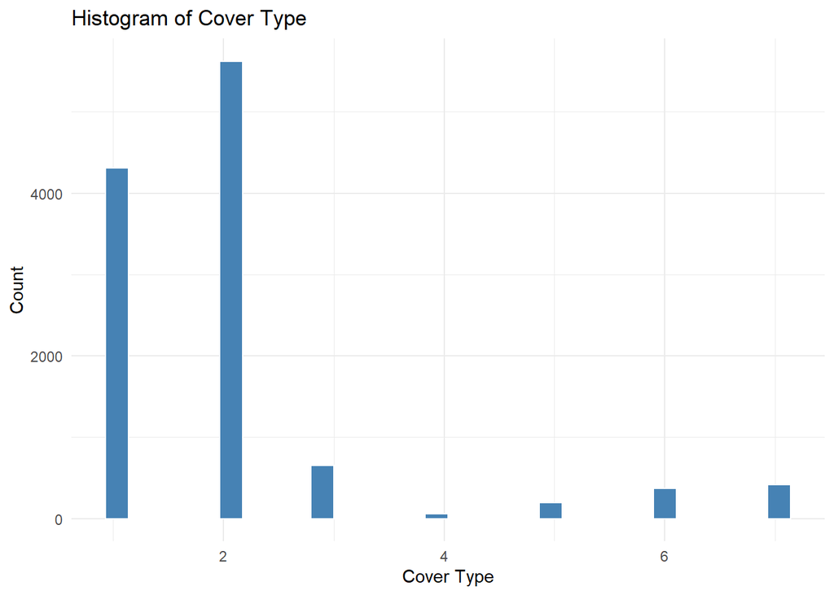

```r
# Perform some exploratory data analysis
# Summary statistics
summary(data)

# Histogram of Cover_Type
ggplot(data, aes(x = Cover_Type)) +
  geom_histogram(fill = "steelblue", color = "white") +
  theme_minimal() +
  labs(x = "Cover Type", y = "Count", title = "Histogram of Cover Type")
```

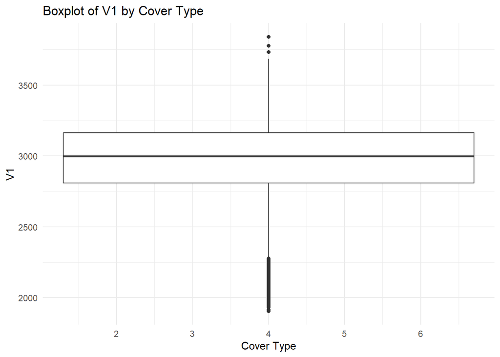

[output not shown]

[output cut: 43 more lines]

[output not shown]

```r
# Boxplot of first variable
ggplot(data, aes(x = Cover_Type, y = V1)) +
  geom_boxplot() +
  theme_minimal() +
  labs(x = "Cover Type", y = "V1", title = "Boxplot of V1 by Cover Type")
```

## 2.2 Data Pre-Processing

```r
# Perform some data pre-processing
# Normalize the numeric variables
numeric_vars <- Filter(is.numeric, data)
data[ , names(numeric_vars)] <- scale(numeric_vars)

# Convert Cover_Type to factor
data$Cover_Type <- as.factor(data$Cover_Type)
```

# 3 Fitting Unparallelized Models

Fitting the control caret model (no hyperparams).

```r
# Fit an ANN model using caret
set.seed(123)
model_caret_control <- train(Cover_Type~., data = trainData, method = "nnet", trace = FALSE, allowParallel=FALSE)
```

Fitting the control h2o model (no hyperparams).

```r
# Fit an ANN model using h2o with no hyperparameters
set.seed(123)
h2o.init(nthreads = -1)
data_h2o <- as.h2o(trainData)
model_h2o_control <- h2o.deeplearning(x = 1:54,
                                        y = 55,
                                        training_frame = data_h2o)
```

```
 Connection successful!

R is connected to the H2O cluster:
    H2O cluster uptime:         16 minutes 34 seconds
    H2O cluster timezone:       America/New_York
    H2O data parsing timezone:  UTC
    H2O cluster version:        3.40.0.4
    H2O cluster version age:    1 month and 24 days
    H2O cluster name:           H2O_started_from_R_fuchs_osn291
    H2O cluster total nodes:    1
    H2O cluster total memory:   3.09 GB
    H2O cluster total cores:    12
    H2O cluster allowed cores:  12
    H2O cluster healthy:        TRUE
    H2O Connection ip:          localhost
    H2O Connection port:        54321
    H2O Connection proxy:       NA
    H2O Internal Security:      FALSE
    R Version:                  R version 4.3.0 (2023-04-21 ucrt)
```

# 4 Fitting Parallelized Models

Fitting the parallelized caret model

```r
set.seed(123)
# Define the control parameters
ctrl <- trainControl(method = "cv", number = 5)

# Define the hyperparameter search grid
grid <- expand.grid(.size = c(5, 10), .decay = c(0.1, 0.5))

# Fit the model with caret
set.seed(123)
model_caret_parallel <- train(Cover_Type~., data = trainData, method = "nnet",
                     trControl = ctrl, tuneGrid = grid, trace = FALSE)
```

Now for H2o we have a simple grid for the hidden and rate parameters, which are analogous to the size and decay parameters in caret’s nnet:

```r
set.seed(123)
# Define the hyperparameters
hyper_params <- list(hidden = list(c(5, 5), c(10, 10)),
                     rate = c(0.1, 0.5))

# Define the search criteria
search_criteria <- list(strategy = "RandomDiscrete",
                        max_models = 20,
                        seed = 123)

# Fit the model with h2o
set.seed(123)
grid <- h2o.grid("deeplearning", x = 1:54, y = 55,
                 training_frame = data_h2o,
                 hyper_params = hyper_params,
                 search_criteria = search_criteria)

# Get the best model
model_h2o_parallel <- h2o.getModel(grid@model_ids[[1]])
```

# 5 Results and Discussion

## 5.1 Performance Metrics

```r
# Get the training times
time_caret_control <- model_caret_control$results$elapsed
time_caret_parallel <- model_caret_parallel$results$elapsed

time_h2o_control <- model_h2o_control@model$run_time
time_h2o_parallel <- model_h2o_parallel@model$run_time

# Create a data frame for plotting
training_times <- data.frame(
  Method = c("Caret", "H2O"),
  Time_Control = c(time_caret_control, time_h2o_control),
  Time_Parallel = c(time_caret_parallel, time_h2o_parallel)
)

#
training_times_long <- training_times %>%
  pivot_longer(cols = c(Time_Control, Time_Parallel),
               names_to = "Type",
               values_to = "Time")
```

## 5.2 Plots

Bar Plot:

[figure not shown]

```r
ggplot(training_times_long, aes(x = Method, y = Time, fill = Type)) +
  geom_bar(stat = "identity", position = "dodge") +
  theme_minimal() +
  labs(x = "Method", y = "Time", fill = "Type",
       title = "Comparison of Training Times by Method and Type")
```